# Telecom_Churn_Group_Case_Study

### 1. Logistic Regression

Defining Custom Methods

```python
def ModelFit(alg, X_train, y_train, performCV=True, cv_folds=5):
    #Fit the algorithm on the data
    alg.fit(X_train, y_train)

    #Predict training set:
    dtrain_predictions = alg.predict(X_train)
    dtrain_predprob = alg.predict_proba(X_train)[:,1]

    #Perform cross-validation:
    if performCV:
        cv_score = cross_val_score(alg, X_train, y_train, cv=cv_folds, scoring='roc_auc')

    #Print model report:
    print ("\nModel Report")
    print ("Accuracy : %.4g" % metrics.roc_auc_score(y_train, dtrain_predictions))
    print ("Recall/Sensitivity : %.4g" % metrics.recall_score(y_train, dtrain_predictions))
    print ("AUC Score (Train): %f" % metrics.roc_auc_score(y_train, dtrain_predprob))

    if performCV:
        print ("CV Score : Mean - %.7g , Std - %.7g , Min - %.7g , Max - %.7g" % (np.mean(cv_score),np.std(cv_score),np.min(cv_score),np.max(cv_score)))
```

```python
def ModelMetrics(actual_churn=False,pred_churn=False):

    confusion = metrics.confusion_matrix(actual_churn, pred_churn)

    TP = confusion[1,1] # true positive
    TN = confusion[0,0] # true negatives
    FP = confusion[0,1] # false positives
    FN = confusion[1,0] # false negatives

    print("roc_auc_score : {}".format(metrics.roc_auc_score(actual_churn,pred_churn)))
    # Let's see the sensitivity of our logistic regression model
    print('Sensitivity/Recall : {}'.format(TP / float(TP+FN)))
    # Let us calculate specificity
    print('Specificity: {}'.format(TN / float(TN+FP)))
    # Calculate false postive rate - predicting churn when customer does not have churned
    print('False Positive Rate: {}'.format(FP/ float(TN+FP)))
    # positive predictive value
    print('Positive predictive value: {}'.format(TP / float(TP+FP)))
    # Negative predictive value
    print('Negative Predictive value: {}'.format(TN / float(TN+ FN)))
    # sklearn precision score value
    print('sklearn precision score value: {}'.format(metrics.precision_score(actual_churn, pred_churn )))
```

```python
def PredictChurnWithProbability(model,X,y,prob):
    # Funtion to predict the churn using the input probability cut-off
    # Input arguments: model instance, x and y to predict using model and cut-off probability

    # predict
    pred_probs = model.predict_proba(X)[:,1]

    y_df= pd.DataFrame({'churn':y, 'churn_Prob':pred_probs})
    # Creating new column 'predicted' with 1 if Churn_Prob>0.5 else 0
    y_df['final_predicted'] = y_df.churn_Prob.map( lambda x: 1 if x > prob else 0)
    # Let's see the head
    ModelMetrics(y_df.churn,y_df.final_predicted)
    return y_df
```

```python
def PlotROC( actual, probs ):
    fpr, tpr, thresholds = metrics.roc_curve( actual, probs,
                                              drop_intermediate = False )
    auc_score = metrics.roc_auc_score( actual, probs )
    plt.figure(figsize=(6, 6))
    plt.plot( fpr, tpr, label='ROC curve (area = %0.2f)' % auc_score )
    plt.plot([0, 1], [0, 1], 'k--')
    plt.xlim([0.0, 1.0])
    plt.ylim([0.0, 1.05])
    plt.xlabel('False Positive Rate or [1 - True Negative Rate]')
    plt.ylabel('True Positive Rate')
    plt.title('Receiver operating characteristic example')
    plt.legend(loc="lower right")
    plt.show()

    return fpr, tpr, thresholds
```

```python
def FindOptimalCutoff(df):
    #Function to find the optimal cutoff for classifing as churn/non-churn
    # Let's create columns with different probability cutoffs
    numbers = [float(x)/10 for x in range(10)]
    for i in numbers:
        df[i] = df.churn_Prob.map( lambda x: 1 if x > i else 0)
    #print(df.head())

    # Now let's calculate accuracy sensitivity and specificity for various probability cutoffs.
    cutoff_df = pd.DataFrame( columns = ['prob','accuracy','sensi','speci'])
    from sklearn.metrics import confusion_matrix

    # TP = confusion[1,1] # true positive
    # TN = confusion[0,0] # true negatives
    # FP = confusion[0,1] # false positives
    # FN = confusion[1,0] # false negatives

    num = [0.0,0.1,0.2,0.3,0.4,0.5,0.6,0.7,0.8,0.9]
    for i in num:
        cm1 = metrics.confusion_matrix(df.churn, df[i] )
        total1=sum(sum(cm1))
        accuracy = (cm1[0,0]+cm1[1,1])/total1

        speci = cm1[0,0]/(cm1[0,0]+cm1[0,1])
        sensi = cm1[1,1]/(cm1[1,0]+cm1[1,1])
        cutoff_df.loc[i] =[ i ,accuracy,sensi,speci]
    print(cutoff_df)
    # Let's plot accuracy sensitivity and specificity for various probabilities.
    cutoff_df.plot.line(x='prob', y=['accuracy','sensi','speci'])
    plt.show()
```

```python
#Training the model on the train data
from sklearn.linear_model import LogisticRegression
from sklearn import metrics

LRModel = LogisticRegression(class_weight='balanced')
```

```python
ModelFit(LRModel, X_train_pca, y_train_res)
```

```
Model Report
Accuracy : 0.827
Recall/Sensitivity : 0.8417
AUC Score (Train): 0.899922
CV Score : Mean - 0.899092 , Std - 0.002047475 , Min - 0.8965539 , Max - 0.9027485
```

```python
# predictions on Test data
pred_probs_test = LRModel.predict(X_test_pca)
ModelMetrics(y_test,pred_probs_test)
```

```
roc_auc_score : 0.8176059484622296
Sensitivity/Recall : 0.8203342618384402
Specificity: 0.8148776350860188
False Positive Rate: 0.1851223649139811
Positive predictive value: 0.27822390174775624
Negative Predictive value: 0.9811816192560175
sklearn precision score value: 0.27822390174775624
```

```python
print("Accuracy : {}".format(metrics.accuracy_score(y_test,pred_probs_test)))
print("Recall : {}".format(metrics.recall_score(y_test,pred_probs_test)))
print("Precision : {}".format(metrics.precision_score(y_test,pred_probs_test)))
```

```
Accuracy : 0.81531431119037
Recall : 0.8203342618384402
Precision : 0.27822390174775624
```

```python
#Making prediction on the test data
pred_probs_train = LRModel.predict_proba(X_train_pca)[:,1]
print("roc_auc_score(Train) {:2.2}".format(metrics.roc_auc_score(y_train_res, pred_probs_train)))
```

```
roc_auc_score(Train) 0.9
```

```python
cut_off_prob=0.5
y_train_df = PredictChurnWithProbability(LRModel,X_train_pca,y_train_res,cut_off_prob)
y_train_df.head()
```

```
roc_auc_score : 0.8269730685244878
Sensitivity/Recall : 0.8416865966517625
Specificity: 0.8122595403972133
False Positive Rate: 0.18774045960278674
Positive predictive value: 0.8176262626262626
Negative Predictive value: 0.8368866509535033
sklearn precision score value: 0.8176262626262626
```

|  | churn | churn_Prob | final_predicted |
| --- | --- | --- | --- |
| 0 | 0 | 0.721737 | 1 |
| 1 | 0 | 0.008851 | 0 |
| 2 | 0 | 0.124666 | 0 |
| 3 | 0 | 0.022137 | 0 |
| 4 | 0 | 0.839900 | 1 |

**Plotting the ROC Curve :** An ROC curve demonstrates several things:

- It shows the tradeoff between sensitivity and specificity (any increase in sensitivity will be accompanied by a decrease in specificity).
- The closer the curve follows the left-hand border and then the top border of the ROC space, the more accurate the test.
- The closer the curve comes to the 45-degree diagonal of the ROC space, the less accurate the test.

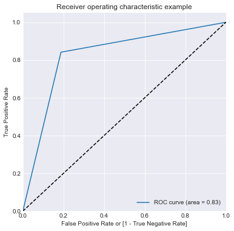

```
roc_auc_score : 0.83
```

```python
PlotROC(y_train_df.churn, y_train_df.final_predicted)
print("roc_auc_score : {:2.2f}".format(metrics.roc_auc_score(y_train_df.churn, y_train_df.final_predicted)))
```

The roc curve is lying in the top left corner which is a good fit.

#### Finding Optimal Cutoff Point

Since recall or sensitivity is a much more important metrics for churn prediction. A trade off between sensitivity(or recall) and specificity is to be considered in doing so. We will try adjusting the probability threshold which shall lead to higher sensitivity or recall rate.

```
     prob  accuracy     sensi     speci
0.0   0.0  0.500000  1.000000  0.000000
0.1   0.1  0.672585  0.980087  0.365083
0.2   0.2  0.742383  0.954404  0.530363
0.3   0.3  0.784808  0.920921  0.648695
0.4   0.4  0.813273  0.886191  0.740356
0.5   0.5  0.826973  0.841687  0.812260
0.6   0.6  0.828403  0.782573  0.874233
0.7   0.7  0.814313  0.712956  0.915670
0.8   0.8  0.773474  0.596340  0.950608
0.9   0.9  0.596756  0.208381  0.985130
```

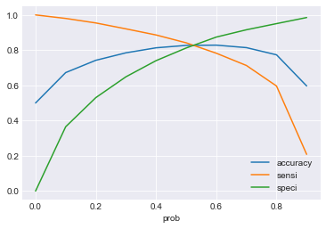

```python
# finding cut-off with the right balance of the metrices
# sensitivity vs specificity trade-off
FindOptimalCutoff(y_train_df)
```

Although, other cutoff between 0.4 and 0.6 can also be taken but to keep the test sensitivity/recall significant we choose 0.45. At this point there is a balance of sensitivity, specificity and accuracy.

Let us predit with the cutt-off

```python
# predicting with the choosen cut-off on train
cut_off_prob = 0.45
PredictChurnWithProbability(LRModel,X_train_pca,y_train_res,cut_off_prob)
```

```
roc_auc_score : 0.8212020380576063
Sensitivity/Recall : 0.8647707185192888
Specificity: 0.7776333575959239
False Positive Rate: 0.2223666424040761
Positive predictive value: 0.795456719273075
Negative Predictive value: 0.8518623989064814
sklearn precision score value: 0.795456719273075
```

|  | churn | churn_Prob | final_predicted |
| --- | --- | --- | --- |
| 0 | 0 | 0.721737 | 1 |
| 1 | 0 | 0.008851 | 0 |
| 2 | 0 | 0.124666 | 0 |
| 3 | 0 | 0.022137 | 0 |
| 4 | 0 | 0.839900 | 1 |
| ... | ... | ... | ... |
| 38463 | 1 | 0.835216 | 1 |
| 38464 | 1 | 0.880460 | 1 |
| 38465 | 1 | 0.737598 | 1 |
| 38466 | 1 | 0.875088 | 1 |
| 38467 | 1 | 0.882487 | 1 |

38468 rows × 3 columns

### Test Predictions

```python
# predicting with the choosen cut-off on test
PredictChurnWithProbability(LRModel,X_test_pca,y_test,cut_off_prob)
```

```
roc_auc_score : 0.812180031898099
Sensitivity/Recall : 0.8440111420612814
Specificity: 0.7803489217349164
False Positive Rate: 0.2196510782650836
Positive predictive value: 0.25051674245556016
Negative Predictive value: 0.9829085914848161
sklearn precision score value: 0.25051674245556016
```

|  | churn | churn_Prob | final_predicted |
| --- | --- | --- | --- |
| 4265 | 0 | 0.441472 | 0 |
| 29221 | 0 | 0.580771 | 1 |
| 974 | 0 | 0.392250 | 0 |
| 1602 | 0 | 0.307631 | 0 |
| 10225 | 0 | 0.158507 | 0 |
| ... | ... | ... | ... |
| 6262 | 0 | 0.204060 | 0 |
| 1424 | 0 | 0.042641 | 0 |
| 18308 | 0 | 0.265123 | 0 |
| 22978 | 0 | 0.106381 | 0 |
| 17728 | 0 | 0.225184 | 0 |

8972 rows × 3 columns

The resulting model, after PCA and logistic regression (with optimal cutoff setting) has a right balance of different metrics score for sensitivity, specificity and Roc Accuracy on the train and test set.

- train sensitivity : 86.47%, train roc auc score : 82.1%
- test sensitivity : 84.40%, test roc auc score : 81.21%